# Covariate Cleaning

Mia Charifson

2024-01-22

```r
pat_cohort <- read.csv('Data/Derived/pat_cohort_w_censoring.csv')
ART_use <- read.csv('Data/Epic/table3_dx_ARTuse.csv')
empy_status <- read.csv('Data/Epic/table6_empy_status.csv')
enc_info_baseline <- read.csv('Data/Epic/table6_enc_info_baseline.csv')
ethnicity <- read.csv('Data/Epic/table6_ethnicity.csv')
marital <- read.csv('Data/Epic/table6_marital_status.csv')
ob_baseline <- read.csv("Data/Epic/table6_ob_baseline.csv")
race <- read.csv('Data/Epic/table6_race.csv')
edu <- read.csv('Data/Epic/table6_social_edu.csv')
lang_nativity <- read.csv('Data/Epic/table6_lang_nativity.csv')
occupn <- read.csv('Data/Epic/table6_occupn_baseline.csv')
insur_baseline <- read.csv('Data/Epic/table6_insurance_baseline.csv')
hc_use_dx <- read.csv('Data/Epic/table3_dx_HCuse.csv')
hc_use_social <- read.csv('Data/Epic/table6_social_HCuse.csv')
prior_delivery_baseline <- read.csv('Data/Epic/table3_dx_prior_delivery.csv')
```

```r
# print percent pretty
print_percent <- function(number) {
  return(paste0(round(number, 3)*100, '%'))
}
# clean NULL to NA and subset covariate files to pat cohort
subset_clean <- function(df) {
  return(df %>%
           filter(pat_id %in% pat_cohort$pat_id) %>%
           mutate(across(where(is.character), ~na_if(., "NULL")))
         )
}
# check unique number of patients
check_unique <- function(df) {
  if (length(unique(df$pat_id))[1]==dim(df)[1]) {
    reply <- "CHECK PASSED, UNIQUE ROW PER PATIENT"
  } else {
    reply <- "CHECK FAILED, MORE THEN ONE ROW FOR SOME PATIENTS"
  }
  return(print(reply))
}
```

# Covariate Cleaning

The purpose of this document is to:

1. derive covariates that are not pre-specified in the data which includes:
- Hospital Site
- Healthcare utilization (HCU)
- Socioeconomic variables (educational attainment & employment)
- Insurance status
- ART use
- Hormonal Contraceptive Use

Additional covariates already derived but that need to be cleaned are:

- Race/ethnicity
- Age
- Parity
- Preferred Language
- Marital status
- Hormonal contraceptive use
- Nativity/Immigration Status
- BMI
2. explore distributions of the covariates
3. explore missingness of the covariates

## 1: Derive Covariates

```r
enc_info_baseline <- subset_clean(enc_info_baseline) %>% mutate(bmi = as.numeric(bmi))
ethnicity <- subset_clean(ethnicity) %>% select(-raw_ethnicity_background) %>%
  mutate(fhc_ethnicity = ifelse(grepl('Unreported|Unmapped', fhc_value), NA, fhc_value))
race <- subset_clean(race) %>% select(-race_name) %>%
  mutate(fhc_race_group = na_if(fhc_race_group, 'Unreported/Refused to Report Race'))
hc_use_social <- subset_clean(hc_use_social)
ob_baseline <- subset_clean(ob_baseline) %>%
  select(-pat_enc_csn_id, -contact_date, -index_enc_date, -margin, -rwn) %>%
  mutate(across(contains('ob'), ~as.numeric(.)))
lang_nativity <- subset_clean(lang_nativity)
insur_baseline <- subset_clean(insur_baseline)
marital <- subset_clean(marital)
edu <- subset_clean(edu)
empy_status <- subset_clean(empy_status)
prior_delivery_baseline <- subset_clean(prior_delivery_baseline)
```

### Primary Encounter Location

Hospital site was defined at baseline and during follow-up. The hospital site chosen was the most common hospital site for relevant care encounters in the first two years of follow-up (before 2019-12-31) and following the first two years of follow-up until the end of follow-up.

If a hospital site was available as the most common site, this was selected. However, if the patient ONLY attended relevant care encounters at outpatient clinics. Their site was specified as “OTHER”. We also allow a patient’s most common ‘site’ to be telemedicine, as this is informative to where and how they receive their care.

### Healthcare utilization

Healthcare utilization at baseline and throughout follow-up was derived in step 1.0.

Healthcare utilization at baseline is defined as the number of relevant care encounters in the first year since their index encounter. If they have none, their value is set to 0.

Healthcare utilization throughout follow-up is defined as the number of relevant care encounters per calendar year (including the first year).

### Educational attainment

There are 1995 patients with any educational attainment information.

```r
clean_edu <- edu %>%
  mutate(across(where(is.character), ~na_if(., "NULL"))) %>%
  filter(!is.na(edu_level) | !is.na(years_education)) %>%
  left_join(pat_cohort %>% select(pat_id, age_20160801, index_enc_date), by = 'pat_id') %>%
  mutate(margin = abs(difftime(index_enc_date, contact_date, units='day')))
```

These come in the form of highest level of education (categorical) (n=221 unique patients report) and number of years of education (free text) (n=1909 unique patients report).

This doesn’t seem worth it to clean since only 2.7%% of patients have anything to clean at all.

```r
edu_new <- edu %>%
  mutate(across(where(is.character), ~na_if(., "NULL"))) %>%
  filter(!is.na(edu_level) | !is.na(years_education))
#unique(edu$edu_level)
#length(unique(edu$pat_id[!is.na(edu$years_education) & is.na(edu$edu_level)]))
#length(unique(edu$pat_id[!is.na(edu$edu_level)]))

below_GED <- c('11th grade', '8th grade')
GED_equivalent <- c('GED or equivalent', '12th grade', 'High school graduate')
some_college <- c('Some college, no degree', 'Associate degree: occupational, technical, or vocational program', "Associate degree: academic program")
college <- c("Bachelor's degree (e.g., BA, AB, BS)")
some_grad_school <- c("Master's degree (e.g., MA, MS, MEng, MEd, MSW, MBA)",
                      "Professional school degree (e.g., MD, DDS, DVM, JD)",
                      "Doctorate")

edu_new <- edu_new %>%
  mutate(edu_level_new = case_when(edu_level %in% below_GED ~ 'Below GED',
                                   edu_level %in% GED_equivalent ~ 'GED or equivalent',
                                   edu_level %in% some_college ~ 'Some college (including associates)',
                                   edu_level %in% college ~ 'College (BA, AB, BS)',
                                   edu_level %in% some_grad_school ~ 'Any graduate schooling',
                                   TRUE~NA))

CreateTableOne(data=edu_new %>% filter(!is.na(edu_level)), vars=c('edu_level', 'edu_level_new'))
```

```r
edu_new %>%
  left_join(pat_cohort %>% select(pat_id, age_20160801), by='pat_id') %>%
  filter(!is.na(years_education)) %>%
  mutate(years_edu_num = as.numeric(str_extract(years_education, '[0-9]+')),
         year_type = case_when(grepl('grade|th', tolower(years_education))~'grade',
                               grepl('(?:year|yr).*(coll)',tolower(years_education),perl=TRUE)~'college',
                               TRUE~NA)) %>%
  filter(years_edu_num == 12 & year_type == 'grade') %>%
  select(pat_id, age_20160801, years_education, years_edu_num, year_type) %>%
  distinct() %>%
  arrange(desc(age_20160801))
  #filter(!is.na(years_edu_num)) %>% group_by(years_education, years_edu_num, year_type) %>%
  #summarise(count=n(), .groups='drop') %>% arrange(year_type, years_edu_num) %>%
  mutate(edu_level_new = case_when(years_edu_num %in% c(1:11) &
                                     year_type == 'grade'~'Below GED',
                                   years_edu_num %in% c(12, 112) &
                                     year_type == 'grade'~'GED or equivalent',
                                   years_edu_num %in% c(13:15)~'Some college',
                                   years_edu_num %in% c(1:3) &
                                     year_type == 'college'~'Some college',
                                   years_edu_num >= 16 ~'College or higher',
                                   years_edu_num==4 &
                                     year_type == 'college' ~'College or higher',
                                   grepl(grad_strings, years_education)~'College or higher')) %>%
  CreateTableOne(data=., vars='edu_level_new', includeNA=TRUE)
```

```r
# 11th grade
edu_new$years_edu_clean[grepl('5th|8th|9th|10th|11th', tolower(edu_new$years_education))] <- 'Below GED'
edu_new$years_edu_clean[grepl('high s', tolower(edu_new$years_education))
                               & grepl('sen|some|junior|last|ing', tolower(edu_new$years_education))] <- 'Below GED'
# 12th grade
edu_new$years_edu_clean[grepl('12', tolower(edu_new$years_education))] <- 'GED or equivalent'
edu_new$years_edu_clean[grepl('high s', tolower(edu_new$years_education))
                               & !grepl('sen|some|junior|last|ing', tolower(edu_new$years_education))] <- 'GED or equivalent'
# some college
edu_new$years_edu_clean[grepl('some|year|yr|in|freshman|junior', tolower(edu_new$years_education))
                        & !grepl('prep|finished|complete', tolower(edu_new$years_education))
                        & grepl('coll|assoc', tolower(edu_new$years_education)) ] <- 'Some college, including Associates'
# bachelors
edu_new$years_edu_clean[grepl('bac|BA|BS|Bach', edu_new$years_education)
                        & !grepl('MBA|-BBA|BBA-', edu_new$years_education)] <- 'College (BA, AB, BS)'
edu_new$years_edu_clean[!grepl('some|year|yr|in|freshman|junior|prep|jr', tolower(edu_new$years_education))
                        & grepl('coll', tolower(edu_new$years_education))] <- 'College (BA, AB, BS)'
# master's
edu_new$years_edu_clean[grepl('MA|mas|Mas|MAS|MS', edu_new$years_education)
                        & !grepl('NMS', edu_new$years_education)] <- 'Any graduate schooling'
# graduate school
grad_strings <- c('doct|grad school|law|medical|graduate level|graduate school|meng|msw|mba|mph|phd|ph. d|ph.d|md|jd|dds|dvm|ma|ms|ba|bs')
edu_new$years_edu_clean[grepl(grad_strings, tolower(edu_new$years_education))] <- 'Any graduate schooling'
```

```r
CreateTableOne(data=edu_new, vars=c('years_edu_clean'), includeNA = TRUE)
#unique(edu_new$years_education[which(is.na(edu_new$years_edu_clean))])
```

### Employment Status

There are 56184 patients with employment status information and 31363 with occupation information.

```r
empy_clean <- empy_status %>%
  left_join(pat_cohort %>% select(pat_id, index_enc_date), by='pat_id') %>%
  mutate(margin = difftime(change_time, index_enc_date, unit='days'),
         margin = as.numeric(margin),
         old_empy_status = case_when(grepl('NULL|Unknown', old_empy_status)~NA,
                                        TRUE~old_empy_status),
         new_empy_status = case_when(grepl('NULL|Unknown', new_empy_status)~NA,
                                        TRUE~new_empy_status)) %>%
  group_by(pat_id) %>%
  filter(min(abs(margin)) == abs(margin)) %>%
  ungroup() %>%
  # if either is missing take the one that isn't missing, otherwise take according to date
  mutate(employ_clean = case_when(is.na(old_empy_status) | is.na(new_empy_status)~
                                               coalesce(new_empy_status, old_empy_status),
                                             index_enc_date < change_time~old_empy_status,
                                             index_enc_date >= change_time~new_empy_status)) %>%
  filter(!is.na(employ_clean)) %>%
  select(pat_id, employ_clean, margin) %>%
  mutate(source = 'empy_status')
```

After cleaning the employment status table, there are 42816 patients had an employment status at some point, which we can use for their baseline employment status.

20487 are employment statuses reported after their index encounter.

```r
unique(occupn$hx_occupn[which(grepl('none|not|unem|n/a|umep|unep|disable|disability',
                                     tolower(occupn$hx_occupn)) &
                                 !grepl('art|work|dame|analyst|sales', tolower(occupn$hx_occupn)))])
unique(occupn$hx_occupn[which(occupn$hx_occupn=="" | occupn$hx_occupn==".")])
unique(occupn$hx_occupn[which(grepl('part ', tolower(occupn$hx_occupn)))])
unique(occupn$hx_occupn[which(grepl('retired', tolower(occupn$hx_occupn)))])

unique(occupn$hx_occupn[which(grepl('no empleo|nort em|nt em', tolower(occupn$hx_occupn)))])
```

```r
umemployed_strs <- c('none|not|unem|n/a|umep|unep|disabled|disability|no empleo|nort em|nt em')

occupn_clean <- occupn %>%
  select(pat_id, hx_occupn, margin) %>%
  distinct() %>%
  mutate(occupn_clean = case_when(hx_occupn == '   ' | hx_occupn == '.'~NA,
                                  grepl('prefer|refuse|discuss', tolower(hx_occupn))~NA,
                                  TRUE~tolower(hx_occupn)),
         employ_clean = case_when(grepl('student', occupn_clean)~'Student',
                                     grepl('part ', occupn_clean)~'Part Time',
                                     grepl('self em|self-em', occupn_clean)~'Self Employed',
                                     grepl('retired', occupn_clean)~'Retired',
                                     grepl(umemployed_strs,occupn_clean) &
                                       !grepl('art|work|dame|analyst|sales',occupn_clean)~'Not Employed',
                                     !is.na(occupn_clean)~'Employed (unspecific)',
                                     TRUE~NA)) %>%
  filter(!is.na(employ_clean)) %>%
  select(pat_id, employ_clean, margin) %>%
  mutate(source = 'occupn_hx')
```

```r
employment_final <- empy_clean %>%
  bind_rows(occupn_clean) %>%
  group_by(pat_id) %>%
  filter(margin == min(margin)) %>%
  mutate(employ_simple_final = case_when(employ_clean %in% c('Employed (unspecific)', 'On Active Military Duty',
                                                             'Full Time', 'Self Employed', 'Part Time')~'Employed',
                                         grepl('Student', employ_clean)~'Student',
                                         TRUE~employ_clean))
```

```r
check_unique(employment_final)
```

```
## [1] "CHECK PASSED, UNIQUE ROW PER PATIENT"
```

```r
employment_final %>%
  filter(!is.na(empy_status_baseline) & !is.na(empy_status_new)) %>%
  select(pat_id, emply_final, empy_status_baseline, margin, empy_status_new)
```

### Insurance status

In 2017, the percent of US Americans on some kind of public health insurance was 34-37% (based on US Census data[https://www.census.gov/content/dam/Census/library/publications/2022/demo/p60-278.pdf]) This includes medicare, medicaid, VA, CHAMPVA plans and NYS specific plans (child & family health plus, managed care plans, essential plans).

There are some index encounters with missing insurance information. They are predominantly from FHC encounters. It is unclear if this is because the patient had no insurnace or it was not entered for another reason.

```r
insur_baseline_unique <- insur_baseline %>%
  mutate(pat_enc_csn_id = as.character(pat_enc_csn_id),
         enc_date = as.Date(enc_date, '%Y-%m-%d')) %>%
  inner_join(pat_cohort %>%
               select(pat_id, all_pat_enc_csn_id, index_enc_date) %>%
               mutate(index_enc_date = as.Date(index_enc_date, '%Y-%m-%d')),
             by=c('pat_id'='pat_id', 'enc_date'='index_enc_date'))
```

For insurance status at baseline, I used the plan names to map to public plans and assumed all other patients with plans at baseline are private plans.

```r
length(unique(insur_baseline$payor_name))
length(unique(insur_baseline$benefit_plan_name))

length(which(grepl('medicare', tolower(unique(insur_baseline$benefit_plan_name)))))
unique(insur_baseline$benefit_plan_name)[which(grepl('medicare', tolower(unique(insur_baseline$benefit_plan_name))))]

length(which(grepl('medicaid', tolower(unique(insur_baseline$benefit_plan_name)))))
unique(insur_baseline$benefit_plan_name)[which(grepl('medicaid', tolower(unique(insur_baseline$benefit_plan_name))))]

length(which(grepl('managed', tolower(unique(insur_baseline$benefit_plan_name)))))
unique(insur_baseline$benefit_plan_name)[which(grepl('managed', tolower(unique(insur_baseline$benefit_plan_name))))]

length(which(grepl('family health', tolower(unique(insur_baseline$benefit_plan_name)))))
unique(insur_baseline$benefit_plan_name)[which(grepl('family health', tolower(unique(insur_baseline$benefit_plan_name))))]

length(which(grepl('veteran', tolower(unique(insur_baseline$benefit_plan_name)))))
unique(insur_baseline$benefit_plan_name)[which(grepl('veteran', tolower(unique(insur_baseline$benefit_plan_name))))]

length(which(grepl('champva', tolower(unique(insur_baseline$benefit_plan_name)))))

length(which(grepl('child health', tolower(unique(insur_baseline$benefit_plan_name)))))
unique(insur_baseline$benefit_plan_name)[which(grepl('child health', tolower(unique(insur_baseline$benefit_plan_name))))]

length(which(grepl('essential', tolower(unique(insur_baseline$benefit_plan_name)))))
unique(insur_baseline$benefit_plan_name)[which(grepl('essential', tolower(unique(insur_baseline$benefit_plan_name))))]

length(which(grepl('healthy new york', tolower(unique(insur_baseline$benefit_plan_name)))))
```

```r
public_plans <- 'medicare|medicaid|family health|veteran|champva|healthy new york|child health|essential|healthfirst|metroplus|mcd|1199'

insur_clean <- insur_baseline_unique %>%
  filter(!is.na(benefit_plan_name)) %>%
  mutate(insur_status = case_when(grepl(public_plans, tolower(benefit_plan_name))~'public',
                                  TRUE~'private')) %>%
  distinct(pat_id, enc_date, payor_name, benefit_plan_name, insur_status, .keep_all = TRUE)

# length(which(insur_clean$insur_status == 'public'))/dim(insur_clean)[1]
# checking percent matches the national/state average
```

```r
insur_clean %>%
  filter(insur_status == 'private') %>%
  distinct(payor_name, benefit_plan_name)
```

```r
check_unique(insur_clean)
```

```
## [1] "CHECK FAILED, MORE THEN ONE ROW FOR SOME PATIENTS"
```

```r
insur_clean_unique <- insur_clean %>%
  distinct(pat_id, enc_date, insur_status)

check_unique(insur_clean_unique)
```

```
## [1] "CHECK PASSED, UNIQUE ROW PER PATIENT"
```

Overall coverage of insurance status at baseline in this cohort: 94%% of patients.

### Assisted Reproductive Technology (ART) Use

For ART use, we are interested in (1) if a patient had use ART prior to baseline and (2) if they use ART at some point during follow-up (if they do receive ART care during FU then we also want to record the date of the earliest ART). We assume that if they do not have any diagnosis codes for ART in their EHR then they do not have ART use. This is a strong assumption given that patients can receive ART care outside of NYU, but we assume this would be indicated somewhere in their EHR considering they receive regular and relevant care at NYU.

```r
remove_ART <- "Conceived by in vitro fertilization|History of in vitro fertilization"

ART_clean <- ART_use %>%
  filter(!grepl(remove_ART, dx_name)) %>%
  left_join(pat_cohort %>% select(pat_id, index_enc_date), by='pat_id') %>%
  mutate(dx_date = as.Date(dx_date),
         dx_window = case_when(dx_date <= index_enc_date~'baseline',
                               TRUE~'fu')) %>%
  group_by(pat_id, dx_window) %>%
  reframe(ART_use = sum(!is.na(dx_date))>=1,
            ART_use_date = pmin(dx_date, na.rm = TRUE)) %>%
  pivot_wider(names_from = dx_window, values_from = c(ART_use, ART_use_date),
              values_fn = mean) %>%
  mutate(ART_use_baseline = ifelse(ART_use_baseline==1, TRUE, FALSE),
         ART_use_fu = ifelse(ART_use_fu==1, TRUE, FALSE))
```

```r
check_unique(ART_clean)
```

```
## [1] "CHECK PASSED, UNIQUE ROW PER PATIENT"
```

Patients with indications of ART use in this cohort: 2.1%% of patients.

### Race and Ethnicity

When cleaning the race and ethnicity data for missingness I use the following assumptions:

1. If race is missing but ethnicity is not missing and is not set to ‘Hispanic/Latino’ or ‘Non-Hispanic/Latino’, then race is set to the value of ethnicity.
- Limitation: this assumes only partial info on this patient’s race given they could have other unreported racial groups.
2. If ethnicity is missing but race = ‘Hispanic/Latino’, then ethnicity is set to ‘Hispanic/Latino’.
3. If ethnicity or race is anything other than ‘Hispanic/Latino’ more than once (they enter their race or ethnicity multiple times and multiple times do not indicate Hispanic/Latino), then their ethnicity is assumed to be ‘Non-Hispanic/Latino’.
- Limitation: this does not impute ethnicity for patient’s with race reported only once, but makes an assumption based on the quantity of data.
4. In the merged race and ethnicity variable, we make the following choices:
- if someone reports more than one race, then they are labelled ‘Multiple races’
- if someone reports being Hispanic/Latino, then they are labelled ‘Hispanic/Latino’, therefore all race categories are labelled as non-Hispanic (NH)

```r
# get distinct instances of race, ethnicity and number of times the patient indicated that identity
race_ethnic <- race %>%
  group_by(pat_id, fhc_race_group) %>%
  summarise(race_count=sum(!is.na(fhc_race_group)), .groups='drop') %>%
  full_join(ethnicity %>%
              group_by(pat_id, fhc_ethnicity) %>%
              summarise(ethnicity_count=sum(!is.na(fhc_ethnicity)), .groups='drop'),
            by='pat_id')

ethnicity_strings <- c('Non-Hispanic/Latino', 'Hispanic/Latino')
# create final version of race and ethnicity
race_ethnic <- race_ethnic %>% group_by(pat_id) %>%
  mutate(race_final = case_when(!is.na(fhc_race_group) & !fhc_race_group %in% ethnicity_strings~fhc_race_group,
                                !is.na(fhc_ethnicity) & !fhc_ethnicity %in% ethnicity_strings~fhc_ethnicity,
                                #is.na(fhc_race_group) & fhc_ethnicity!='Non-Hispanic/Latino'~fhc_ethnicity,
                                TRUE~NA),
         ethnicity_final = case_when(fhc_ethnicity %in% ethnicity_strings~fhc_ethnicity,
                                     fhc_race_group %in% ethnicity_strings~fhc_race_group,
                                     !is.na(fhc_ethnicity) & !fhc_ethnicity %in% ethnicity_strings &
                                       ethnicity_count > 1~'Non-Hispanic/Latino',
                                     !is.na(fhc_race_group) & !fhc_race_group %in% ethnicity_strings &
                                       race_count > 1~'Non-Hispanic/Latino',
                                     TRUE~NA))
```

```r
# look at cross-tab between race and ethnicity
race_ethnic %>%
  tableby(formula=~race_final+ethnicity_final, data=., test=FALSE) %>%
  summary()
```

|  | Overall (N=78696) |
| --- | --- |
| **race_final** |  |
| N-Miss | 20070 |
| American Indian/Alaska Native | 723 (1.2%) |
| Asian | 6269 (10.7%) |
| Black/African American | 10518 (17.9%) |
| Native Hawaiian | 3 (0.0%) |
| Pacific Islander | 102 (0.2%) |
| Unmapped | 467 (0.8%) |
| White | 40544 (69.2%) |
| **ethnicity_final** |  |
| N-Miss | 15224 |
| Hispanic/Latino | 16427 (25.9%) |
| Non-Hispanic/Latino | 47045 (74.1%) |

```r
multiple_races <- race_ethnic %>%
  select(pat_id, race_final) %>%
  filter(!is.na(race_final)) %>%
  distinct() %>%
  group_by(pat_id) %>%
  filter(n()>1) %>%
  arrange(pat_id)
```

There are 611 patients who reported multiple races. The common combinations are:

```r
multiple_races %>%
  group_by(pat_id) %>%
  mutate(num = row_number()) %>%
  ungroup() %>%
  pivot_wider(id_cols = 'pat_id',
              names_from = 'num',
              names_prefix = 'race_',
              values_from = 'race_final') %>%
  group_by(race_1, race_2, race_3, race_4) %>%
  summarise(count=n(), .groups='drop') %>%
  arrange(desc(count)) %>%
  select(race_1, race_2, count) %>%
  head(10) %>%
  kable(caption = 'Top ten racial combinations of multiracial patients') %>% kable_styling()
```

Top ten racial combinations of multiracial patients

| race_1 | race_2 | count |
| --- | --- | --- |
| Asian | White | 230 |
| Black/African American | White | 185 |
| American Indian/Alaska Native | White | 41 |
| Asian | Black/African American | 37 |
| American Indian/Alaska Native | Black/African American | 36 |
| American Indian/Alaska Native | Black/African American | 29 |
| Asian | Unmapped | 11 |
| Unmapped | White | 9 |
| American Indian/Alaska Native | Asian | 6 |
| Asian | Black/African American | 6 |

```r
race_ethnic_final <- race_ethnic %>%
  group_by(pat_id) %>%
  filter(n()==1 | (n()>1 & !is.na(race_final))) %>%
  group_by(pat_id) %>%
  reframe(race_groups = case_when(n_distinct(race_final)>1~paste0(unique(race_final),collapse = ', '),
                                   TRUE~NA),
            race_final = case_when(n_distinct(race_final)>1~'Multiple races',
                                   n_distinct(race_final)==1~race_final,
                                   TRUE~NA),
            ethnicity_final = case_when(sum(!is.na(ethnicity_final))==1~ethnicity_final,
                                        sum(!is.na(ethnicity_final))>1 &
                                          sum(ethnicity_final=='Hispanic/Latino')>=1~'Hispanic/Latino',
                                        sum(!is.na(ethnicity_final))>1 &
                                          sum(ethnicity_final=='Hispanic/Latino')==0~'Non-Hispanic/Latino',
                                   TRUE~NA)) %>%
  distinct() %>%
  mutate(race_ethnic_final = case_when(ethnicity_final=='Hispanic/Latino'~ethnicity_final,
                                       !is.na(race_final)~str_c('NH ', race_final)))
```

```r
check_unique(race_ethnic_final)
```

```
## [1] "CHECK FAILED, MORE THEN ONE ROW FOR SOME PATIENTS"
```

```r
race_ethnic_final %>% group_by(pat_id) %>% filter(n()>1) %>% arrange(pat_id)
```

```
## # A tibble: 1,336 × 5
## # Groups:   pat_id [668]
##    pat_id   race_groups race_final             ethnicity_final     race_ethnic…¹
##    <chr>    <chr>       <chr>                  <chr>               <chr>
##  1 Z1039287 <NA>        White                  Non-Hispanic/Latino NH White
##  2 Z1039287 <NA>        White                  <NA>                NH White
##  3 Z1060818 <NA>        White                  Hispanic/Latino     Hispanic/Lat…
##  4 Z1060818 <NA>        White                  <NA>                NH White
##  5 Z1077963 <NA>        Black/African American <NA>                NH Black/Afr…
##  6 Z1077963 <NA>        Black/African American Hispanic/Latino     Hispanic/Lat…
##  7 Z1145261 <NA>        White                  Non-Hispanic/Latino NH White
##  8 Z1145261 <NA>        White                  <NA>                NH White
##  9 Z1173068 <NA>        White                  Hispanic/Latino     Hispanic/Lat…
## 10 Z1173068 <NA>        White                  <NA>                NH White
## # … with 1,326 more rows, and abbreviated variable name ¹race_ethnic_final
```

```r
# keep row with the least missingness
race_ethnic_unique <- race_ethnic_final %>%
  mutate(nmiss = rowSums(is.na(.))) %>%
  group_by(pat_id) %>%
  filter(nmiss==min(nmiss)) %>%
  select(-nmiss)
```

```r
check_unique(race_ethnic_unique)
```

```
## [1] "CHECK PASSED, UNIQUE ROW PER PATIENT"
```

### Hormonal Contraceptive (HC) Use

Hormonal contraceptive (HC) use is defined as use of any form of hormonal contraceptive (IUD, pill, injectable, implant, patch, ring) at the time of baseline or close to the time of baseline (within one year). The two sources for HC use are (1) indication of some type of HC use in the social baseline table or (2) diagnosis code for prescription for or surveillance of HC. Both of these are ONLY positive indicators of HC use. This means we will likely have many false negatives by missing indication of HC use if they are not prescribed at NYU and not recorded in the social baseline survey for patients.

We take any positive indication from either source to count. Positive indication for each is defined as:

- social baseline survey: (1) is their index encounter between the start/check-up date for an HC and another HC social history indicator? or (2) in the year after baseline encounter, do they have any true HC screen? This means at some point in the baseline year following entry into cohort they used a HC.
- diagnosis codes: (1) is their index encounter between the start/check-up date for an HC and another HC encounter (of any type)? or (2) in the year after baseline encounter, do they have any encounter for HC (this includes starting, continuing or ending HC use)? This means at some point in the baseline year following entry into cohort they used a HC.

```r
hc_social_clean <- hc_use_social %>%
  inner_join(pat_cohort %>% select(pat_id, index_enc_date), by='pat_id') %>%
  mutate(contact_date = as.Date(contact_date), index_enc_date = as.Date(index_enc_date)) %>%
  group_by(pat_id) %>%
  mutate(next_hc_enc = lead(contact_date),
         HC_status = case_when((index_enc_date >= contact_date & index_enc_date <= next_hc_enc)~TRUE,
                               between(as.numeric(contact_date-index_enc_date), 0, 365) ~ TRUE,
                               TRUE~FALSE),
         source = 'social_history')
#length(unique(hc_social_clean$pat_id[which(hc_social_clean$HC_status)]))
```

```r
hc_dx_clean <- hc_use_dx %>%
  filter(!grepl('condom|barrier', tolower(dx_name))) %>%
  inner_join(pat_cohort %>% select(pat_id, index_enc_date), by='pat_id') %>%
  mutate(dx_date = as.Date(dx_date), index_enc_date = as.Date(index_enc_date)) %>%
  arrange(pat_id, dx_date) %>%
  mutate(HC_enc_type = case_when(grepl('Z30.432', icd10)~'end',
                                 grepl('removal|pregnancy', tolower(dx_name)) &
                                   !grepl('reinsertion', tolower(dx_name))~'end',
                                 TRUE~'not end'),
         hc_type = case_when(grepl('Z30.011|Z30.41', icd10)~'pill',
                                grepl('Z30.014|Z30.43[0-3]', icd10)~'iud',
                                grepl('Z30.013|Z30.42', icd10)~'injectable',
                                grepl('Z30.015|Z30.44', icd10)~'ring',
                                grepl('Z30.016|Z30.45', icd10)~'patch',
                                grepl('Z30.017|Z30.46', icd10)~'implant',
                                grepl('Z30.012', icd10)~'emergency',
                                grepl('bcp|oral|pill', tolower(dx_name))~'pill',
                                grepl('iud|intrauterine|uterin contracep dev',
                                      tolower(dx_name))~'iud',
                                grepl('depo|inject|medroxy', tolower(dx_name))~'injectable',
                                grepl('ring|intravaginal', tolower(dx_name)) &
                               !grepl('monitoring|occurring|during', dx_name)~'ring',
                                grepl('patch|transdermal', tolower(dx_name))~'patch',
                                grepl('implant|implanon|subdermal|nexplanon|norplant',
                                      tolower(dx_name))~'implant',
                                TRUE~'other')) %>%
  filter(hc_type != 'emergency') %>%
  group_by(pat_id) %>%
  mutate(next_hc_enc = lead(dx_date),
         HC_status = case_when((index_enc_date >= dx_date & index_enc_date <= next_hc_enc) &
                                 HC_enc_type != 'end'~TRUE,
                               between(as.numeric(dx_date-index_enc_date), 0, 365) ~ TRUE,
                               TRUE~FALSE),
         source = 'diagnosis_codes') %>%
  ungroup()
```

```r
hc_dx_clean %>%
  group_by(pat_id) %>%
  filter(sum(HC_status)==0 & sum(year(dx_date)==year(index_enc_date))>=1) %>%
  select(-pat_enc_csn_id, -dx_type, -referral_id) %>%
  View()

hc_dx_clean %>%
  group_by(pat_id) %>%
  filter(HC_status) %>%
  select(-pat_enc_csn_id, -dx_type, -referral_id) %>%
  View()

## based on both sources how many contraceptive users should there be
length(unique(c(hc_dx_clean$pat_id[which(hc_dx_clean$HC_status)], hc_social_clean$pat_id[which(hc_social_clean$HC_status)])))
```

```r
hc_baseline_clean <- hc_social_clean %>%
  filter(HC_status) %>%
  select(pat_id, HC_status, hc_type) %>%
  bind_rows(hc_dx_clean %>%
              filter(HC_status) %>%
              select(pat_id, HC_status, hc_type, source)) %>%
  distinct() %>%
  group_by(pat_id) %>%
  # remove duplicates where the type is other or emergency in favor of the duplicate which is not that
  filter(n()==1 | (n()>1 & !hc_type %in% c('other', 'emergency'))) %>%
  summarise(HC_status = case_when(sum(HC_status) >= 1~TRUE,
                                  n() == sum(!HC_status)~FALSE),
            HC_type = paste0(unique(hc_type[HC_status]), collapse = ', '),
            .groups='drop')
```

```r
check_unique(hc_baseline_clean)
```

```
## [1] "CHECK PASSED, UNIQUE ROW PER PATIENT"
```

Patients with indications of HC information in this cohort: 19.9%% of patients.

We assume if they do NOT have positive indication of HC use at baseline than they were not using HC at baseline (this likely underestimates the true rate and has high false negative rate).

This table shows the number of patients at baseline who were on some form of hormonal contraceptive and the methods of contraceptive used. Some patients indicated multiple methods so they may sum to more than 100% of the patients with `HC_status=TRUE`.

```r
hc_baseline_clean %>%
  mutate(iud = ifelse(grepl('iud', HC_type), TRUE, FALSE),
         pill = ifelse(grepl('pill', HC_type), TRUE, FALSE),
         other = ifelse(grepl('implant|injection|ring|patch', HC_type), TRUE, FALSE)) %>%
  tableby(formula = ~iud+pill+other, data=.) %>%
  summary()
```

|  | Overall (N=14783) |
| --- | --- |
| **iud** |  |
| FALSE | 9010 (60.9%) |
| TRUE | 5773 (39.1%) |
| **pill** |  |
| FALSE | 8675 (58.7%) |
| TRUE | 6108 (41.3%) |
| **other** |  |
| FALSE | 13273 (89.8%) |
| TRUE | 1510 (10.2%) |

### Parity

Parity is derived from the obstetric history questionnaire (voluntary completed for a patient) or via any indication of prior delivery in diagnosis codes prior to 2017-12-31.

If they have parity > 0 or indiciation of a prior delivery before end of baseline, they are considered parous. If they have a parity = 0, they are considered nulliparous.

We could also assume no indication of prior delivery means nulliparous, but given most patients who do have parity > 1 do not also have a prior indication of delivery, I think this would be a false assumption.

```r
parity_clean <- ob_baseline %>%
  mutate(parity_final = coalesce(ob_parity, ob_live_births, ob_full_term)) %>%
  select(-contains('ob')) %>%
  full_join(prior_delivery_baseline %>% mutate(prior_delivery = as.logical(prior_delivery)), by='pat_id') %>%
  mutate(parity_binary = case_when(parity_final == 0~'nulliparous',
                                 parity_final >= 1~'parous',
                                 prior_delivery~'parous'))
```

```r
check_unique(parity_clean)
```

```
## [1] "CHECK PASSED, UNIQUE ROW PER PATIENT"
```

Patients with indications of parity information in this cohort: 59.6%% of patients.

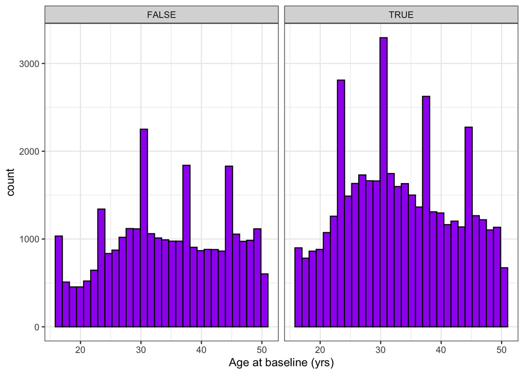

```r
pat_cohort %>%
  mutate(parity_flag = ifelse(pat_id %in%
                                parity_clean$pat_id[which(!is.na(parity_clean$parity_binary))],
                              TRUE, FALSE)) %>%
  ggplot(aes(x=age_20160801), data=.) +
  geom_histogram(fill='purple', color='black') +
  xlab('Age at baseline (yrs)') +
  facet_grid(~parity_flag) +
  theme_bw()
```

There isn’t a notable age pattern for patients missing parity. Those who are missing parity are on average about a year older but the overall mean and spread are very similar.

### Preferred Language

```r
language_clean <- lang_nativity %>%
  select(pat_id, contains('language'), intrptr_needed_yn) %>%
  distinct() %>%
  mutate(language = coalesce(language_prefer, language_care, language_writ)) %>%
  mutate(language = ifelse(grepl('DO NOT USE', language), NA, language)) %>%
  mutate(language_eng = case_when(language == 'English'~language,
                                  intrptr_needed_yn == 'Y'~'Non-English',
                                  !is.na(language)~'Non-English'),
         language_eng = factor(language_eng)) %>%
   mutate(language_eng_sp = case_when(language %in% c('English', 'Spanish')~language,
                                  !is.na(language)~'Other'),
         language_eng_sp = factor(language_eng_sp))
```

```r
check_unique(language_clean)
```

```
## [1] "CHECK PASSED, UNIQUE ROW PER PATIENT"
```

```r
language_clean %>%
  group_by(language) %>%
  summarise(count=n(), .groups='drop') %>%
  arrange(desc(count)) %>%
  head(10) %>%
  kable(caption = 'Top ten languages in patient cohort') %>%
  kable_styling()
```

Top ten languages in patient cohort

| language | count |
| --- | --- |
| English | 66012 |
| Spanish | 5539 |
| Russian | 821 |
| Chinese - Mandarin | 817 |
| NA | 220 |
| Polish | 175 |
| Chinese - Cantonese | 169 |
| Arabic | 103 |
| Other | 75 |
| Creole - Haitian / Haitian Creole / French Creole | 63 |

### Marital status

```r
marital_clean <- marital %>%
  left_join(pat_cohort %>% select(pat_id, index_enc_date), by='pat_id') %>%
  mutate(margin = difftime(change_time, index_enc_date, unit='days'),
         old_marital_status = case_when(grepl('NULL|Unknown', old_marital_status)~NA,
                                        TRUE~old_marital_status),
         new_marital_status = case_when(grepl('NULL|Unknown', new_marital_status)~NA,
                                        TRUE~new_marital_status),) %>%
  group_by(pat_id) %>%
  filter(min(abs(margin)) == abs(margin)) %>%
  ungroup() %>%
  # if either is missing take the one that isn't missing, otherwise take according to date
  mutate(marital_status_baseline = case_when(is.na(old_marital_status) |
                                               is.na(new_marital_status)~
                                               coalesce(new_marital_status, old_marital_status),
                                             index_enc_date < change_time~old_marital_status,
                                             index_enc_date >= change_time~new_marital_status),
         marital_status_final = case_when(marital_status_baseline %in%
                                            c('Single', 'Divorced', 'Widowed', 'Legally Separated') ~
                                            'Unpartnered',
                                          marital_status_baseline %in%
                                            c('Married', 'Partner', 'Significant Other') ~ 'Partnered',
                                          TRUE~NA))
```

```r
check_unique(marital_clean)
```

```
## [1] "CHECK PASSED, UNIQUE ROW PER PATIENT"
```

### Nativity/Immigration Status

```r
nativity_clean <- lang_nativity %>%
  select(pat_id, country_of_origin, us_citizen_yn, permanent_resident_yn) %>%
  mutate(across(us_citizen_yn:permanent_resident_yn, ~as.factor(.)),
         country_of_origin_clean = ifelse(grepl('Refused|Unknown', country_of_origin), NA,
                                          country_of_origin),
         nativity = case_when(country_of_origin_clean != 'United States of America'~'non-US',
                              permanent_resident_yn == 'Y' ~ 'non-US',
                              us_citizen_yn == 'N' ~ 'non-US',
                              country_of_origin_clean == 'United States of America'~'US',
                              TRUE~NA),
         nativity = as.factor(nativity))
```

```r
check_unique(nativity_clean)
```

```
## [1] "CHECK PASSED, UNIQUE ROW PER PATIENT"
```

22500 patients report a country of origin in their EHR. 8 patients report a permanent resident status in their EHR. 36 patients report a citizenship status in their EHR.

Overall, we can extract nativity for 29.4%.

### BMI

```r
bmi_clean <- enc_info_baseline %>%
  select(pat_id, bmi, enc_date) %>%
  distinct() %>%
  mutate(bmi_clean = as.numeric(bmi),
         bmi_clean = case_when(bmi_clean>10000~bmi_clean/1000,
                               bmi_clean>1000~bmi_clean/100,
                               bmi_clean>100~bmi_clean/10,
                               TRUE~bmi_clean)) %>%
  filter(!is.na(bmi_clean)) %>%
  inner_join(pat_cohort %>% select(pat_id, index_enc_date), by='pat_id') %>%
  mutate(margin = difftime(enc_date, index_enc_date, unit='days')) %>%
  group_by(pat_id) %>%
  filter(min(abs(margin)) == abs(margin)) %>%
  ungroup()
```

Some patients have more than one BMI at baseline so I take the average of these values to derive their baseline BMI.

```r
bmi_unique <- bmi_clean %>%
  group_by(pat_id) %>%
  arrange(pat_id) %>%
  summarise(bmi_baseline = mean(bmi_clean), .groups='drop')
```

```r
check_unique(bmi_unique)
```

```
## [1] "CHECK PASSED, UNIQUE ROW PER PATIENT"
```

There are 72567 patients with a clean BMI at baseline which is 97.7%.

## 2: Explore Distributions of covariates

```r
pat_cohort_covars <- pat_cohort %>%
  select(pat_id, age_20160801, hcu_baseline, hcu_fu, site_baseline) %>%
  left_join(employment_final %>% rename(employ_margin = margin, employ_source = source)
            , by='pat_id') %>%
  left_join(insur_clean_unique %>% select(-enc_date), by='pat_id') %>%
  left_join(ART_clean, by='pat_id') %>%
  left_join(race_ethnic_unique, by='pat_id') %>%
  left_join(hc_baseline_clean, by='pat_id') %>%
  left_join(parity_clean, by='pat_id') %>%
  left_join(language_clean %>% select(pat_id, language_eng_sp, language_eng), by='pat_id') %>%
  left_join(marital_clean %>% select(pat_id, marital_status_final), by='pat_id') %>%
  left_join(bmi_unique, by='pat_id') %>%
  left_join(nativity_clean %>% select(pat_id, nativity), by='pat_id')
```

```r
check_unique(pat_cohort_covars)
```

```
## [1] "CHECK PASSED, UNIQUE ROW PER PATIENT"
```

### Continuous variables

```r
cont_labs <- list(age_20160801 = 'Age (years)',
                  hcu_baseline = 'Healthcare Utilization (baseline)',
                  hcu_fu = 'Healthcare Utilization (follow-up)',
                  bmi_baseline = 'BMI (kg/m^2)')
summary(tableby(~age_20160801 + hcu_baseline + hcu_fu + bmi_baseline, data=pat_cohort_covars),
        labelTranslations = cont_labs)
```

|  | Overall (N=74287) |
| --- | --- |
| **Age (years)** |  |
| Mean (SD) | 33.737 (9.138) |
| Range | 16.000 - 50.000 |
| **Healthcare Utilization (baseline)** |  |
| Mean (SD) | 2.599 (3.779) |
| Range | 0.000 - 136.000 |
| **Healthcare Utilization (follow-up)** |  |
| Mean (SD) | 2.944 (2.026) |
| Range | 1.000 - 58.500 |
| **BMI (kg/m^2)** |  |
| N-Miss | 1720 |
| Mean (SD) | 26.587 (6.531) |
| Range | 0.000 - 86.610 |

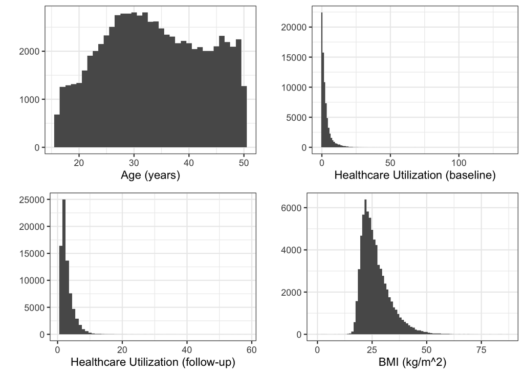

```r
cont_df <- pat_cohort_covars[,c('age_20160801','hcu_baseline', 'hcu_fu','bmi_baseline')]
list <-lapply(1:ncol(cont_df),
              function(col) ggplot2::qplot(cont_df[[col]],
                                           geom = "histogram",
                                           xlab = cont_labs[[col]],
                                           binwidth = 1)+ theme_bw())
cowplot::plot_grid(plotlist = list)
```

### Sociodemographic variables

```r
ses_labs <- list(employ_simple_final = 'Employment status',
                 insur_status = 'Insurance status',
                 race_ethnic_final = 'Race/Ethnicity',
                 language_eng_sp = 'Preferred Language',
                 marital_status_final = 'Marital status',
                 parity_binary = 'Parity',
                 nativity = 'Nativity',
                 site_baseline = 'Hospital Site')
summary(tableby(~employ_simple_final + insur_status + race_ethnic_final + language_eng_sp +
                  marital_status_final + parity_binary + nativity + site_baseline, data=pat_cohort_covars,
                na.action = na.tableby(FALSE)), labelTranslations = ses_labs)
```

|  | Overall (N=74287) |
| --- | --- |
| **Employment status** |  |
| N-Miss | 23274 |
| Employed | 36826 (72.2%) |
| Not Employed | 10602 (20.8%) |
| Retired | 69 (0.1%) |
| Student | 3516 (6.9%) |
| **Insurance status** |  |
| N-Miss | 4437 |
| private | 49214 (70.5%) |
| public | 20636 (29.5%) |
| **Race/Ethnicity** |  |
| N-Miss | 8391 |
| Hispanic/Latino | 15232 (23.1%) |
| NH American Indian/Alaska Native | 55 (0.1%) |
| NH Asian | 5710 (8.7%) |
| NH Black/African American | 9197 (14.0%) |
| NH Multiple races | 510 (0.8%) |
| NH Native Hawaiian | 3 (0.0%) |
| NH Unmapped | 78 (0.1%) |
| NH White | 35111 (53.3%) |
| **Preferred Language** |  |
| N-Miss | 220 |
| English | 66012 (89.1%) |
| Other | 2516 (3.4%) |
| Spanish | 5539 (7.5%) |
| **Marital status** |  |
| N-Miss | 4089 |
| Partnered | 28215 (40.2%) |
| Unpartnered | 41983 (59.8%) |
| **Parity** |  |
| N-Miss | 29996 |
| nulliparous | 22179 (50.1%) |
| parous | 22112 (49.9%) |
| **Nativity** |  |
| N-Miss | 52463 |
| non-US | 10826 (49.6%) |
| US | 10998 (50.4%) |
| **Hospital Site** |  |
| FAMILY HEALTH CENTERS | 12926 (17.4%) |
| NYU LANGONE BROOKLYN | 7170 (9.7%) |
| NYU LANGONE HOSPITAL - LONG ISLAND | 1481 (2.0%) |
| OTHER | 32388 (43.6%) |
| TELEMEDICINE | 676 (0.9%) |
| TISCH HOSPITAL | 19646 (26.4%) |

This is a cross-tabulation of race and ethnicity if we do not merge the two variables.

```r
# look at cross-tab between race and ethnicity
race_ethnic_unique %>%
  tableby(formula=ethnicity_final~race_final, data=., test=FALSE) %>%
  summary()
```

|  | Hispanic/Latino (N=15232) | Non-Hispanic/Latino (N=45508) | Total (N=60740) |
| --- | --- | --- | --- |
| **race_final** |  |  |  |
| N-Miss | 9090 | 2994 | 12084 |
| American Indian/Alaska Native | 524 (8.5%) | 41 (0.1%) | 565 (1.2%) |
| Asian | 134 (2.2%) | 4858 (11.4%) | 4992 (10.3%) |
| Black/African American | 761 (12.4%) | 7900 (18.6%) | 8661 (17.8%) |
| Multiple races | 101 (1.6%) | 357 (0.8%) | 458 (0.9%) |
| Native Hawaiian | 0 (0.0%) | 3 (0.0%) | 3 (0.0%) |
| Pacific Islander | 95 (1.5%) | 0 (0.0%) | 95 (0.2%) |
| Unmapped | 348 (5.7%) | 64 (0.2%) | 412 (0.8%) |
| White | 4179 (68.0%) | 29291 (68.9%) | 33470 (68.8%) |

### ART & HC use

```r
other_labs <- list(ART_use_baseline = 'ART Use prior to baseline',
                 ART_use_fu = 'ART Use during follow-up',
                 HC_status = 'Hormonal Contraceptive use')
# make all NA's FALSE (assumption)
pat_cohort_covars <- pat_cohort_covars %>%
  mutate(ART_use_baseline = ifelse(is.na(ART_use_baseline), FALSE, ART_use_baseline),
         ART_use_fu = ifelse(is.na(ART_use_fu), FALSE, ART_use_fu),
         HC_status = ifelse(is.na(HC_status), FALSE, HC_status),)
summary(tableby(~ART_use_baseline + ART_use_fu + HC_status, data=pat_cohort_covars),
        labelTranslations = other_labs)
```

|  | Overall (N=74287) |
| --- | --- |
| **ART Use prior to baseline** |  |
| FALSE | 74020 (99.6%) |
| TRUE | 267 (0.4%) |
| **ART Use during follow-up** |  |
| FALSE | 73479 (98.9%) |
| TRUE | 808 (1.1%) |
| **Hormonal Contraceptive use** |  |
| FALSE | 59504 (80.1%) |
| TRUE | 14783 (19.9%) |

### Site by other characteristics

```r
summary(tableby(site_baseline~employ_simple_final + insur_status + race_ethnic_final + language_eng_sp +
                  marital_status_final + parity_binary + nativity, data=pat_cohort_covars,
                na.action = na.tableby(FALSE)), labelTranslations = ses_labs)
```

|  | FAMILY HEALTH CENTERS (N=12926) | NYU LANGONE BROOKLYN (N=7170) | NYU LANGONE HOSPITAL - LONG ISLAND (N=1481) | OTHER (N=32388) | TELEMEDICINE (N=676) | TISCH HOSPITAL (N=19646) | Total (N=74287) | p value |
| --- | --- | --- | --- | --- | --- | --- | --- | --- |
| **Employment status** |  |  |  |  |  |  |  | < 0.001 |
| N-Miss | 923 | 1911 | 341 | 14672 | 219 | 5208 | 23274 |  |
| Employed | 5428 (45.2%) | 3611 (68.7%) | 912 (80.0%) | 14396 (81.3%) | 426 (93.2%) | 12053 (83.5%) | 36826 (72.2%) |  |
| Not Employed | 5470 (45.6%) | 1397 (26.6%) | 151 (13.2%) | 2012 (11.4%) | 18 (3.9%) | 1554 (10.8%) | 10602 (20.8%) |  |
| Retired | 8 (0.1%) | 11 (0.2%) | 5 (0.4%) | 35 (0.2%) | 0 (0.0%) | 10 (0.1%) | 69 (0.1%) |  |
| Student | 1097 (9.1%) | 240 (4.6%) | 72 (6.3%) | 1273 (7.2%) | 13 (2.8%) | 821 (5.7%) | 3516 (6.9%) |  |
| **Insurance status** |  |  |  |  |  |  |  | < 0.001 |
| N-Miss | 3052 | 225 | 22 | 640 | 34 | 464 | 4437 |  |
| private | 1646 (16.7%) | 4234 (61.0%) | 984 (67.4%) | 24941 (78.6%) | 609 (94.9%) | 16800 (87.6%) | 49214 (70.5%) |  |
| public | 8228 (83.3%) | 2711 (39.0%) | 475 (32.6%) | 6807 (21.4%) | 33 (5.1%) | 2382 (12.4%) | 20636 (29.5%) |  |
| **Race/Ethnicity** |  |  |  |  |  |  |  | < 0.001 |
| N-Miss | 296 | 726 | 117 | 4660 | 81 | 2511 | 8391 |  |
| Hispanic/Latino | 8154 (64.6%) | 1316 (20.4%) | 265 (19.4%) | 2959 (10.7%) | 86 (14.5%) | 2452 (14.3%) | 15232 (23.1%) |  |
| NH American Indian/Alaska Native | 19 (0.2%) | 4 (0.1%) | 3 (0.2%) | 13 (0.0%) | 0 (0.0%) | 16 (0.1%) | 55 (0.1%) |  |
| NH Asian | 1309 (10.4%) | 268 (4.2%) | 88 (6.5%) | 2051 (7.4%) | 62 (10.4%) | 1932 (11.3%) | 5710 (8.7%) |  |
| NH Black/African American | 2348 (18.6%) | 980 (15.2%) | 285 (20.9%) | 3621 (13.1%) | 49 (8.2%) | 1914 (11.2%) | 9197 (14.0%) |  |
| NH Multiple races | 32 (0.3%) | 41 (0.6%) | 10 (0.7%) | 218 (0.8%) | 13 (2.2%) | 196 (1.1%) | 510 (0.8%) |  |
| NH Native Hawaiian | 0 (0.0%) | 0 (0.0%) | 0 (0.0%) | 2 (0.0%) | 0 (0.0%) | 1 (0.0%) | 3 (0.0%) |  |
| NH Unmapped | 32 (0.3%) | 5 (0.1%) | 2 (0.1%) | 24 (0.1%) | 0 (0.0%) | 15 (0.1%) | 78 (0.1%) |  |
| NH White | 736 (5.8%) | 3830 (59.4%) | 711 (52.1%) | 18840 (67.9%) | 385 (64.7%) | 10609 (61.9%) | 35111 (53.3%) |  |
| **Preferred Language** |  |  |  |  |  |  |  | < 0.001 |
| N-Miss | 12 | 42 | 1 | 148 | 0 | 17 | 220 |  |
| English | 6967 (53.9%) | 6690 (93.9%) | 1400 (94.6%) | 30872 (95.8%) | 665 (98.4%) | 19418 (98.9%) | 66012 (89.1%) |  |
| Other | 1060 (8.2%) | 193 (2.7%) | 10 (0.7%) | 1102 (3.4%) | 8 (1.2%) | 143 (0.7%) | 2516 (3.4%) |  |
| Spanish | 4887 (37.8%) | 245 (3.4%) | 70 (4.7%) | 266 (0.8%) | 3 (0.4%) | 68 (0.3%) | 5539 (7.5%) |  |
| **Marital status** |  |  |  |  |  |  |  | < 0.001 |
| N-Miss | 106 | 373 | 43 | 1643 | 35 | 1889 | 4089 |  |
| Partnered | 5345 (41.7%) | 2877 (42.3%) | 632 (43.9%) | 12390 (40.3%) | 254 (39.6%) | 6717 (37.8%) | 28215 (40.2%) |  |
| Unpartnered | 7475 (58.3%) | 3920 (57.7%) | 806 (56.1%) | 18355 (59.7%) | 387 (60.4%) | 11040 (62.2%) | 41983 (59.8%) |  |
| **Parity** |  |  |  |  |  |  |  | < 0.001 |
| N-Miss | 3179 | 3209 | 413 | 15870 | 268 | 7057 | 29996 |  |
| nulliparous | 2126 (21.8%) | 1652 (41.7%) | 392 (36.7%) | 9689 (58.7%) | 263 (64.5%) | 8057 (64.0%) | 22179 (50.1%) |  |
| parous | 7621 (78.2%) | 2309 (58.3%) | 676 (63.3%) | 6829 (41.3%) | 145 (35.5%) | 4532 (36.0%) | 22112 (49.9%) |  |
| **Nativity** |  |  |  |  |  |  |  | < 0.001 |
| N-Miss | 861 | 4712 | 963 | 28633 | 603 | 16691 | 52463 |  |
| non-US | 8483 (70.3%) | 746 (30.3%) | 158 (30.5%) | 909 (24.2%) | 9 (12.3%) | 521 (17.6%) | 10826 (49.6%) |  |
| US | 3582 (29.7%) | 1712 (69.7%) | 360 (69.5%) | 2846 (75.8%) | 64 (87.7%) | 2434 (82.4%) | 10998 (50.4%) |  |

Patients who only attend outpatient clinics in their baseline year appear to most closely resemble Tisch patients. They are predominantly privately insured, employed, non-Hispanic White (highest proportion of all sites), English speakers, and native (although among the highest missingness for all SES variables).

## 3: Explore Missingness of covariates

### Percent missing per variable

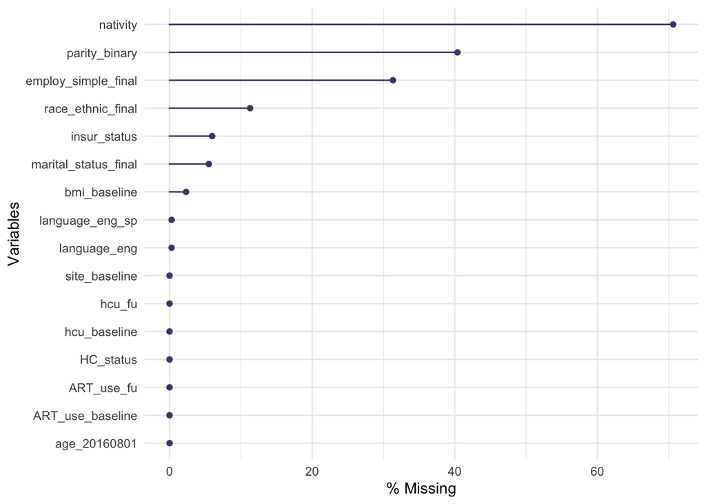

```r
gg_miss_var(pat_cohort_covars %>%
              select(-c(pat_id, race_groups, employ_source, employ_margin,
                        employ_clean, parity_final, prior_delivery, race_final, ethnicity_final,
                        contains('date'), HC_type)),
            show_pct = TRUE)
```

Because nativity missingess is so high, we will not use it for future missingness descriptives

### Missingness pattern across variables

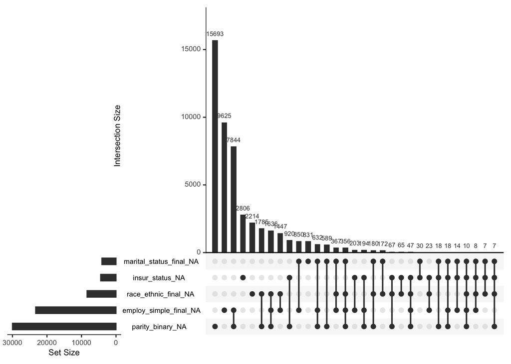

```r
gg_miss_upset(pat_cohort_covars %>%
                select(-c(pat_id, race_groups, employ_source, employ_margin, parity_final, prior_delivery,
                          employ_clean, race_final, ethnicity_final, nativity,
                          contains('date'), HC_type)))
```

```r
summary(tableby(language_eng_sp~insur_status, data=pat_cohort_covars,
                na.action = na.tableby(FALSE)), labelTranslations = ses_labs)
```

|  | English (N=66012) | Other (N=2516) | Spanish (N=5539) | Total (N=74067) | p value |
| --- | --- | --- | --- | --- | --- |
| **Insurance status** |  |  |  |  | < 0.001 |
| N-Miss | 2084 | 318 | 2683 | 4437 |  |
| private | 48120 (75.0%) | 516 (21.3%) | 425 (13.8%) | 49214 (70.5%) |  |
| public | 16028 (25.0%) | 1902 (78.7%) | 2651 (86.2%) | 20636 (29.5%) |  |

Spanish speakers have a higher proportion of missing insurance (48%) vs. English (3%) vs. Other (12%). Therefore, having missing insurance does appear to be associated with being a Spanish speaker.

### Complete case descriptives

```r
pat_cohort_covars$complete <- complete.cases(pat_cohort_covars[,c("insur_status",
                                                                  "race_ethnic_final",
                                                                  "language_eng_sp",
                                                                  "marital_status_final",
                                                                  "bmi_baseline",
                                                                  "hcu_baseline",
                                                                  "site_baseline",
                                                                  "employ_simple_final",
                                                                  "parity_binary")])

summary(tableby(complete ~ site_baseline + age_20160801 + bmi_baseline + parity_binary + insur_status +
                  race_ethnic_final + language_eng_sp + marital_status_final + employ_simple_final +
                  ART_use_baseline + HC_status + hcu_baseline,
                data=pat_cohort_covars, na.action = na.tableby(FALSE)),
        labelTranslations = c(cont_labs, ses_labs, other_labs))
```

|  | FALSE (N=49138) | TRUE (N=25149) | Total (N=74287) | p value |
| --- | --- | --- | --- | --- |
| **Hospital Site** |  |  |  | < 0.001 |
| FAMILY HEALTH CENTERS | 6496 (13.2%) | 6430 (25.6%) | 12926 (17.4%) |  |
| NYU LANGONE BROOKLYN | 4574 (9.3%) | 2596 (10.3%) | 7170 (9.7%) |  |
| NYU LANGONE HOSPITAL - LONG ISLAND | 761 (1.5%) | 720 (2.9%) | 1481 (2.0%) |  |
| OTHER | 24913 (50.7%) | 7475 (29.7%) | 32388 (43.6%) |  |
| TELEMEDICINE | 449 (0.9%) | 227 (0.9%) | 676 (0.9%) |  |
| TISCH HOSPITAL | 11945 (24.3%) | 7701 (30.6%) | 19646 (26.4%) |  |
| **Age (years)** |  |  |  | 0.360 |
| Mean (SD) | 33.759 (9.274) | 33.694 (8.865) | 33.737 (9.138) |  |
| Range | 16.000 - 50.000 | 16.000 - 50.000 | 16.000 - 50.000 |  |
| **BMI (kg/m^2)** |  |  |  | < 0.001 |
| N-Miss | 1720 | 0 | 1720 |  |
| Mean (SD) | 26.434 (6.477) | 26.874 (6.623) | 26.587 (6.531) |  |
| Range | 0.000 - 86.610 | 2.320 - 83.770 | 0.000 - 86.610 |  |
| **Parity** |  |  |  | < 0.001 |
| N-Miss | 29996 | 0 | 29996 |  |
| nulliparous | 10817 (56.5%) | 11362 (45.2%) | 22179 (50.1%) |  |
| parous | 8325 (43.5%) | 13787 (54.8%) | 22112 (49.9%) |  |
| **Insurance status** |  |  |  | < 0.001 |
| N-Miss | 4437 | 0 | 4437 |  |
| private | 33755 (75.5%) | 15459 (61.5%) | 49214 (70.5%) |  |
| public | 10946 (24.5%) | 9690 (38.5%) | 20636 (29.5%) |  |
| **Race/Ethnicity** |  |  |  | < 0.001 |
| N-Miss | 8391 | 0 | 8391 |  |
| Hispanic/Latino | 8315 (20.4%) | 6917 (27.5%) | 15232 (23.1%) |  |
| NH American Indian/Alaska Native | 29 (0.1%) | 26 (0.1%) | 55 (0.1%) |  |
| NH Asian | 3449 (8.5%) | 2261 (9.0%) | 5710 (8.7%) |  |
| NH Black/African American | 5531 (13.6%) | 3666 (14.6%) | 9197 (14.0%) |  |
| NH Multiple races | 310 (0.8%) | 200 (0.8%) | 510 (0.8%) |  |
| NH Native Hawaiian | 3 (0.0%) | 0 (0.0%) | 3 (0.0%) |  |
| NH Unmapped | 40 (0.1%) | 38 (0.2%) | 78 (0.1%) |  |
| NH White | 23070 (56.6%) | 12041 (47.9%) | 35111 (53.3%) |  |
| **Preferred Language** |  |  |  | < 0.001 |
| N-Miss | 220 | 0 | 220 |  |
| English | 43893 (89.7%) | 22119 (88.0%) | 66012 (89.1%) |  |
| Other | 1686 (3.4%) | 830 (3.3%) | 2516 (3.4%) |  |
| Spanish | 3339 (6.8%) | 2200 (8.7%) | 5539 (7.5%) |  |
| **Marital status** |  |  |  | < 0.001 |
| N-Miss | 4089 | 0 | 4089 |  |
| Partnered | 17624 (39.1%) | 10591 (42.1%) | 28215 (40.2%) |  |
| Unpartnered | 27425 (60.9%) | 14558 (57.9%) | 41983 (59.8%) |  |
| **Employment status** |  |  |  | < 0.001 |
| N-Miss | 23274 | 0 | 23274 |  |
| Employed | 18716 (72.4%) | 18110 (72.0%) | 36826 (72.2%) |  |
| Not Employed | 5211 (20.1%) | 5391 (21.4%) | 10602 (20.8%) |  |
| Retired | 39 (0.2%) | 30 (0.1%) | 69 (0.1%) |  |
| Student | 1898 (7.3%) | 1618 (6.4%) | 3516 (6.9%) |  |
| **ART Use prior to baseline** |  |  |  | < 0.001 |
| FALSE | 49066 (99.9%) | 24954 (99.2%) | 74020 (99.6%) |  |
| TRUE | 72 (0.1%) | 195 (0.8%) | 267 (0.4%) |  |
| **Hormonal Contraceptive use** |  |  |  | < 0.001 |
| FALSE | 40657 (82.7%) | 18847 (74.9%) | 59504 (80.1%) |  |
| TRUE | 8481 (17.3%) | 6302 (25.1%) | 14783 (19.9%) |  |
| **Healthcare Utilization (baseline)** |  |  |  | < 0.001 |
| Mean (SD) | 2.144 (3.353) | 3.489 (4.361) | 2.599 (3.779) |  |
| Range | 0.000 - 136.000 | 0.000 - 80.000 | 0.000 - 136.000 |  |

In terms of notable differences, incomplete cases are more likely to:

- have private insurance
- speak English
- be White
- not use hormonal contraceptives

```r
## write out final table with covariates
write.csv(pat_cohort_covars, 'Data/Derived/clean_covariates.csv', row.names=FALSE)
```